# Allocation of Biodiversity Aid: A Social Network Analysis

Final blog post for RI-SP093 class: Social Networks Theories and Methods

Annia Costermani

12/13/2021

# Theoretical Motivations and Hypotheses

Nation-states, multilateral organizations, and funding institutions have set themselves ambitious [global biodiversity conservation](https://www.cbd.int/sp/targets/) and [zero-](https://www.bbc.com/news/science-environment-59088498)[deforestation](https://ukcop26.org/glasgow-leaders-declaration-on-forests-and-land-use/) targets and committed to increasing international finance and aligning financial flows to reach these. They have formed a variety of bilateral, multilateral, and transnational [forest governance](https://www.mdpi.com/2071-1050/12/17/7010) and [funding arrangements](https://www.oecd.org/environment/resources/biodiversity/report-a-comprehensive-overview-of-global-biodiversity-finance.pdf) to ensure the protection of forests and biodiversity. Given that [deforestation](http://www.fao.org/state-of-forests/en/) and [biodiversity loss](https://zenodo.org/record/3553579#.YcRTrhPMK3I) continue to take place at alarming rates and the predominant belief that permanent deforestation is primarily [commodity-driven](https://science.sciencemag.org/content/361/6407/1108) the obvious questions arise:

- What drives bilateral aid allocation?
- Does it reach the countries that need the most support to halt key biodiversity loss and are most affected by commodity-driven deforestation?
- What developmental and biodiversity-related country attributes explain biodiversity aid and forest-related commodity (FRC) trade flows?

The [study of aid allocation](https://onlinelibrary.wiley.com/doi/full/10.1111/j.1467-9361.2011.00605.x?casa_token=QVR9DOIGVyAAAAAA%3AU6lXxM1KK__AECqKE27TGMH1mgV0KMd_okiIimNdYEmb6aBJbVtrOxv7PhvSg8ho_XiSYA6TnW_No0JB2us) has identified that it tends to be allocated according to recipients’ needs and merits and donors’ self-interests. Studies have been done to explain [biodiversity aid allocation](https://www.sciencedirect.com/science/article/abs/pii/S0305750X14000059?via%3Dihub) drivers and [environmental aid](https://onlinelibrary.wiley.com/doi/full/10.1111/1540-6237.8401009-i1?casa_token=Y1Z6wh64qUoAAAAA%3AcLOKtSYBdLj8T5patqTFV6dZZWxEZO0Y7Log8kfyXzf7YSktDZLZKFaFB9KcwWzkScNhfGLossAsbJWHtME) in general, however, few studies have focused on analyzing [dyadic regression analyses of conservation aid](https://www.mdpi.com/1999-4907/11/7/751/htm) and [even fewer](https://refubium.fu-berlin.de/handle/fub188/18560) approaching the question with a [social networks approach](http://www.ramiroberardo.net/uploads/6/0/5/3/60538339/robinsetal_2012.pdf). By following such an approach this study does not assume independence of observations but can control for network structure, the [interdependence](https://ideas.repec.org/p/ces/ceswps/_4177.html) of aid allocation choices by donors, and the dependence on other relational ties between countries (exp. trade).

That is why this analysis focuses on studying the effect of FRC trade network and several country-level node attributes on bilateral biodiversity aid network.

Table 1: Hypotheses of the effects on bilateral biodiversity aid allocation by countries’ biodiversity and development related attributes; dyadic FRC trade ties and non-state biodiversity aid

[output not shown]

# Data and Network visualization

The data collection for this network was done by the author. First, countries most active in importing and exporting FRCs as categorized by the [Global Canopy](https://forest500.org/sites/default/files/2020_country_selection_methodology_0.pdf) and countries with the highest tree cover loss identified by the [WRI](https://research.wri.org/gfr/top-ten-lists) were included as nodes in the first mode of the network. Secondly, non-state donors active in providing biodiversity-related funding were included as nodes in the second mode of the network based on a previous actor analysis study of the [global forest regime.](https://annia-costermani.medium.com/regime-complexity-of-international-forest-governance-7b2a2a01ec99) The network includes 27 country nodes and 8 non-state donor nodes.

The two within mode edges included in the analysis are trade ties (brown) and bilateral biodiversity-related aid ties (green). The between mode edges are non-state biodiversity-related aid ties (gray). All ties are weighted (in Million USD) and are directed, from exporters to importers and from aid donors to aid recipients. Trade ties represent [export flows](https://oec.world/en/visualize/tree_map/hs92/export/bra/all/9/2019/) of [FRC commodities](https://forest500.org/sites/default/files/2020_country_selection_methodology_0.pdf) of key drivers of deforestation of each export country in 2019. Bilateral biodiversity-related aid ties represent [biodiversity rio-marked committed aid flows](https://stats.oecd.org/Index.aspx?DataSetCode=RIOMARKERS) between countries from 2010 to 2019. Non-state biodiversity-related aid ties represent reimbursed aid flows for the biodiversity sector from non-state donors to countries from 2010 to 2019. Trade data was retrieved from t[he Observatory of Economic Complexity (OEC) national trade database](https://oec.world/en) and biodiversity-related aid data was retrieved from the [OECD’s Creditor Reporting System](https://stats.oecd.org/Index.aspx?DataSetCode=RIOMARKERS) database.

Table 2: Descriptive Statistics: Degree centrality in trade, bilateral aid and non-state aid sub-networks

|  | Min | Max | Mean | number of edges |
| --- | --- | --- | --- | --- |
| indegree bilateral aid tie (recipient) | 0.0 | 2,532.36 | 412.81 | 365 |
| outdegree bilateral aid tie (donor) | 0.0 | 3,460.22 | 412.81 | 365 |
| outdegree trade tie (export) | 0.0 | 42,699.08 | 6,031.03 | 133 |
| indegree trade tie (import) | 55.1 | 50,409.87 | 6,031.03 | 133 |
| indegree non-state aid tie (recipient) | 0.0 | 245.00 | 43.62 | 80 |

Several development-related, commodity-related, and biodiversity-related country node attributes were selected as dependent variables (monadic node covariates) that might have an effect on the structure of the trade and biodiversity-aid networks. They reflect the indicators chosen to test the hypotheses (table 1).

Table 3: Descriptive Statistics: Actor Attributes: Total of 27 Countries

|  | unit | Min | Max | Mean |
| --- | --- | --- | --- | --- |
| GDP/capita | constant US$ in 2019 | 489.00 | 60,837.00 | 18,346.26 |
| HDI | index in 2019 with range 0-1 | 0.48 | 0.95 | 0.77 |
| Domestic Consumption | million USD in 2019 | 9,888.01 | 5,549,965.31 | 996,283.54 |
| land mass | million km2 | 0.04 | 17.10 | 2.91 |
| Tree Extent | MHa in 2000 | 0.58 | 761.20 | 113.54 |
| Tree Loss | Mha from 2001-2020 | 0.27 | 69.50 | 12.38 |
| deforestation | Mha from 2001-2020 | 0.00 | 42.46 | 3.95 |
| Key areas for biodiversity | km2 in 2020 | 17,586.00 | 1,677,831.00 | 348,387.74 |
| BHI | index in 2020 with range 0-100 | 39.30 | 82.40 | 57.06 |
| B&H | index in 2020 with range 0-100 | 19.00 | 88.80 | 63.24 |
| Domestic Funding | Biodiversity-related government expenditure in million USD in 2010-2019 | 120.00 | 159,273.00 | 27,579.77 |

A detailed description of the data, data collection, and its limitations can be found in the metadata report of this analysis.

The combination of this data gave rise to a multiplex, 2-mode, directed, and weighted network.

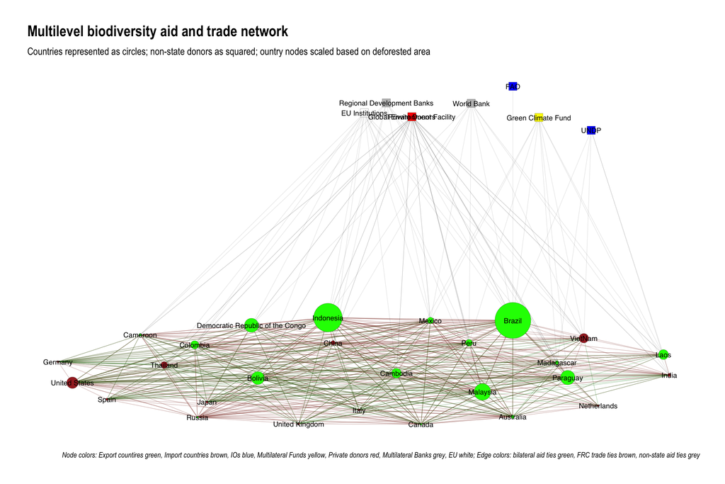

# Data Modelling and Analysis

As the network to be analyzed is weighted and directed there are considerable limitations in the [choice of modelling and analysis techniques](http://www.ramiroberardo.net/uploads/6/0/5/3/60538339/robinsetal_2012.pdf). That is why this study employs a [quadratic assignment procedure (QAP) analysis](https://www.jstor.org/stable/41433301). (MR)QAP helps account for network dependencies, however it is unable to analyse them.

First, the QAP correlation analysis is employed to investigate the simple correlation between bilateral biodiversity aid and trade networks and the monadic node attributes expressed in dyadic relationships through sender and receiver attributes matrices.

Second, the QAP regression analysis (MRQAP) examines how the two potentially contrasting bilateral biodiversity aid and trade ties, along with country attributes, affect the bilateral aid network structure.

Originally, the goal was to study the plotted multilevel network including the second mode of non-state actors and aid ties. Unfortunately, due to limits in the [sna QAP analysis package](https://www.jstatsoft.org/article/view/v024i06), only a one-mode multiplex network could be analyzed. This was done by transforming the non-state aid ties into a node-level attribute of the received volume of non-state funding losing so the two-mode network structure.

## QAP Correlation

### QAP Correlation between bilateral biodiversity aid and trade network

```
## [1] -0.2093123
```

```
##
## QAP Test Results
##
## Estimated p-values:
##  p(f(perm) >= f(d)): 0.964
##  p(f(perm) <= f(d)): 0.039
```

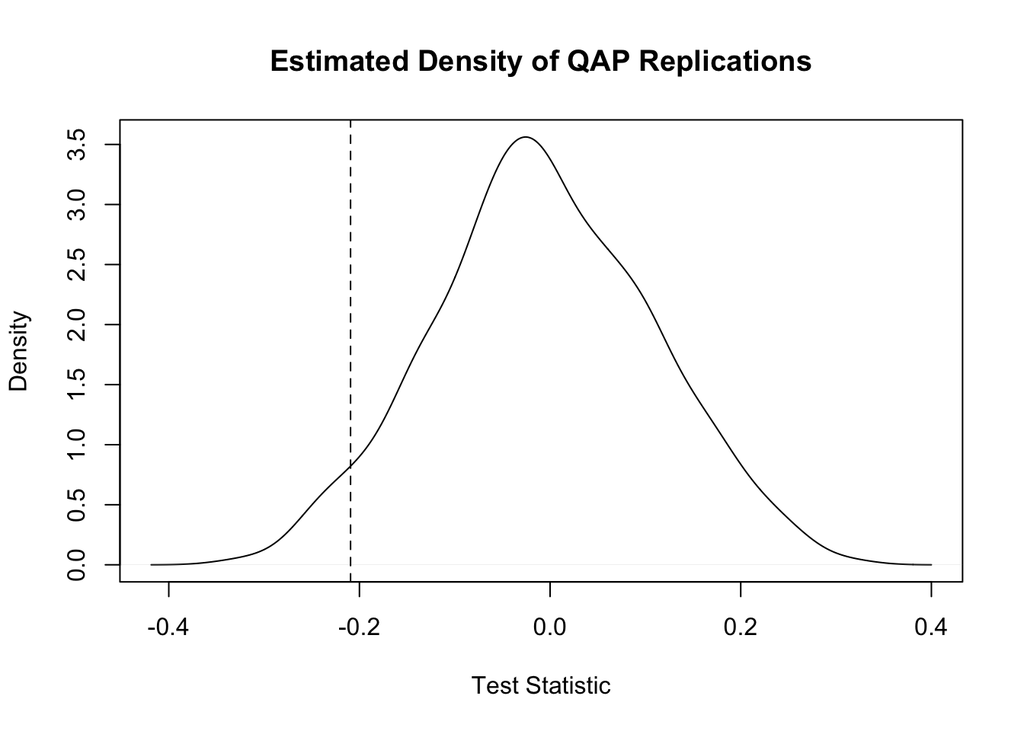

### QAP Correlation between bilateral aid network and country attributes

Table 5: QAP correlations between bilateral aid network and monadic covariates of aid sender and receiver countries

|  | Coefficient | p(f(perm) >= f(d)) | p(f(perm) <= f(d) | two sided p-value |
| --- | --- | --- | --- | --- |
| GDP/capita_R | -0.330 | 1.000 | 0.000 | 0.000 |
| GDP/capita_S | 0.640 | 0.000 | 1.000 | 0.000 |
| HDI_R | -0.310 | 1.000 | 0.000 | 0.000 |
| HDI_S | 0.550 | 0.000 | 1.000 | 0.000 |
| Land_Mass_R | -0.100 | 0.920 | 0.080 | 0.160 |
| Land_Mass_S | 0.070 | 0.350 | 0.650 | 0.700 |
| Tree_Loss_R | -0.050 | 0.740 | 0.260 | 0.520 |
| Tree_Loss_S | -0.006 | 0.510 | 0.490 | 0.980 |
| Tree_Extent_R | -0.050 | 0.750 | 0.250 | 0.500 |
| Tree_Extent_S | -0.050 | 0.600 | 0.400 | 0.800 |
| Deforestation_R | 0.140 | 0.000 | 1.000 | 0.000 |
| Deforestation_S | -0.190 | 0.980 | 0.020 | 0.040 |
| Area_Biodiversity_R | -0.070 | 0.800 | 0.200 | 0.400 |
| Area_Biodiversity_S | 0.090 | 0.240 | 0.760 | 0.480 |
| BHI_R | 0.030 | 0.340 | 0.660 | 0.680 |
| BHI_S | -0.100 | 0.750 | 0.250 | 0.500 |
| B&H_R | -0.180 | 0.996 | 0.004 | 0.008 |
| B&H_S | 0.340 | 0.005 | 0.995 | 0.010 |
| Domestic_Biod._Funding_R | -0.030 | 0.640 | 0.360 | 0.720 |
| Domestic_Biod._Funding_S | 0.090 | 0.260 | 0.750 | 0.510 |
| Multilateral_aid_R | 0.220 | 0.000 | 1.000 | 0.000 |
| Multilateral_aid_S | -0.340 | 1.000 | 0.000 | 0.000 |
| Domestic_Consumption_R | -0.090 | 0.840 | 0.160 | 0.320 |
| Domestic_Consumption_S | 0.390 | 0.017 | 0.983 | 0.034 |

None of the variables have a specially high correlation with the bilateral aid network. The highest correlation is a positive correlation (0.64) between the GDP per capita of the sender and the network. This might also be given by the weight unit of the bilateral aid tie (Million USD).

Only 6 of the tested monadic covariates of the sender and 5 of the receiver were statistically significant (marked in green). These results give us a hint that hypotheses H2, H1 (only by forest-related biodiversity conservation goals) could be correct and H3 wrong.

### QAP Correlation between trade network and country attributes

Table 6: QAP correlations between trade network and monadic covariates of commodity exporter(sender) and importing(receiver) countries

|  | Coefficient | p(f(perm) >= f(d)) | p(f(perm) <= f(d) | two sided p-value |
| --- | --- | --- | --- | --- |
| GDP/capita_R | 0.141 | 1.000 | 0.000 | 0.000 |
| GDP/capita_S | -0.132 | 0.000 | 1.000 | 0.000 |
| HDI_R | 0.199 | 1.000 | 0.000 | 0.000 |
| HDI_S | -0.091 | 0.000 | 1.000 | 0.000 |
| Land_Mass_R | 0.072 | 0.915 | 0.085 | 0.170 |
| Land_Mass_S | 0.446 | 0.329 | 0.671 | 0.658 |
| Tree_Loss_R | 0.025 | 0.741 | 0.259 | 0.518 |
| Tree_Loss_S | 0.471 | 0.492 | 0.508 | 0.984 |
| Tree_Extent_R | 0.020 | 0.766 | 0.234 | 0.468 |
| Tree_Extent_S | 0.438 | 0.608 | 0.392 | 0.784 |
| Deforestation_R | -0.014 | 0.000 | 1.000 | 0.000 |
| Deforestation_S | 0.326 | 0.989 | 0.011 | 0.022 |
| Area_Biodiversity_R | 0.089 | 0.816 | 0.184 | 0.368 |
| Area_Biodiversity_S | 0.440 | 0.274 | 0.726 | 0.548 |
| BHI_R | -0.080 | 0.298 | 0.702 | 0.596 |
| BHI_S | 0.581 | 0.767 | 0.233 | 0.466 |
| B&H_R | 0.011 | 0.997 | 0.003 | 0.006 |
| B&H_S | -0.092 | 0.002 | 0.998 | 0.004 |
| Domestic_Biod._Funding_R | 0.117 | 0.630 | 0.370 | 0.740 |
| Domestic_Biod._Funding_S | 0.127 | 0.276 | 0.724 | 0.552 |
| Multilateral_aid_R | -0.019 | 0.000 | 1.000 | 0.000 |
| Multilateral_aid_S | 0.317 | 1.000 | 0.000 | 0.000 |
| Domestic_Consumption_R | 0.166 | 0.845 | 0.155 | 0.310 |
| Domestic_Consumption_S | 0.289 | 0.013 | 0.987 | 0.026 |

Here too, none of the variables have a specially high correlation with the trade network. The highest is positive correlation(0.58) between the BHI index of the commodity exporter and the network. However this relationship is not statistically significant. The highest statistical significant relationship is a positive correlation between deforestation of the commodity exporter and the network (0.33).

Only 6 of the tested monadic covariates of the exporter and 5 of the importer were statistically significant (marked in green). These results give us a hint that hypothesis 4 (at least for commodity-driven deforestation) could be correct.

## MRQAP

Several models were constructed to test the hypotheses in table 1. Dependent variables were integrated into the models based on their indication of the hypotheses and maximizing the models’ adjusted R-squared values.

Table 7: QAP multiple regression (MRQAP) results of 9 models based on hypotheses in table 1

|  | Model 1: H1 | Model 2: H2 | Model 3: H3 | Model 4: H1&2 | Model 5: H1&3 | Model 6: H1,2,3 | Model 7: H1,H2,H6 | Model 8: H4 | Model 9: H4, H5, H7 |
| --- | --- | --- | --- | --- | --- | --- | --- | --- | --- |
| Intercept | 0.2523 | 0.2141 | -0.0233 | 0.0606 | 0.0535 | 0.0543 | 0.0284 | 0.3876*** | -0.0091 |
| trade_tie |  |  |  |  |  |  |  | 0.0000 | -0.0621* |
| GDP/capita_R |  | -0.0000*** |  | -0.0000*** |  | 0.0000** | 0.0000, | 0.0000** | 0.0000* |
| GDP/capita_S |  | 0.0000*** |  | 0.0000** |  | 0.0000** | 0.0000 | -0.0194* | 0.0000*** |
| HDI_R |  | -0.2216 |  | -0.1750 |  | -0.1526 | -0.1771 |  |  |
| HDI_S |  | 0.0113 |  | 0.0841 |  | 0.1144 | 0.0841 |  |  |
| Land_Mass_R | -0.0015 |  | -0.0117* | 0.0127* | -0.0122 | 0.0097 | 0.0067 |  |  |
| Land_Mass_S | 0.0100 |  | 0.0109 | -0.0183 | 0.0296 | -0.0224 | -0.0183 |  |  |
| Tree_Loss_R | -0.0131 |  |  | 0.0009 | -0.0094* | 0.0001 | 0.0036 |  |  |
| Tree_Loss_S | 0.0317* |  |  | 0.0005 | 0.0248 | -0.0004 | 0.0005 | 0.0020** | -0.0031 |
| Tree_Extent_R | 0.0008 |  |  | -0.0006 | 0.0006 | -0.0005 | -0.0008 |  |  |
| Tree_Extent_S | -0.0029* |  |  | 0.0002 | -0.0026* | 0.0004 | 0.0002 | 0.0135** | 0.0001 |
| Deforestation_R | 0.0120** |  |  | 0.0054* | 0.0110*** | 0.0058* | 0.0020 |  |  |
| Deforestation_S | -0.0173* |  |  | -0.0026 | -0.0155* | -0.0020 | -0.0026 | 0.0000** | 0.0026 |
| Area_Biodiversity_R |  |  |  |  |  |  |  |  |  |
| Area_Biodiversity_S |  |  |  |  |  |  |  |  |  |
| BHI_R | 0.0046 |  |  | 0.0017 | 0.0053** | 0.0021 | 0.0020 |  |  |
| BHI_S | -0.0055 |  |  | 0.0000 | -0.0068 | 0.0005 | 0.0000 |  |  |
| B&H_R |  |  | -0.0038** |  | -0.0042*** | -0.0007 |  |  |  |
| B&H_S |  |  | 0.0072* |  | 0.0078** | -0.0009 |  |  |  |
| Domestic_Biod._Funding_R |  |  |  |  |  |  |  |  |  |
| Domestic_Biod._Funding_S |  |  |  |  |  |  |  |  |  |
| Non-state_aid_R |  |  |  |  |  |  | 0.0005 |  |  |
| Non-state_aid_S |  |  |  |  |  |  |  |  |  |
| Domestic_Consumption_R |  |  |  |  |  |  |  | 0.0000*** | 0.0000* |
| Domestic_Consumption_S |  |  |  |  |  |  |  | 0.0000*** | 0.0000 |
| adjusted R-squared | 0.2037 | 0.5007 | 0.1675 | 0.5221 | 0.3781 | 0.5218 | 0.5239 | 0.2527 | 0.715 |
| model p-value | 0 | 0 | 0 | 0 | 0 | 0 | 0 | 0 | 0 |

[^1]

Model 9 has the highest adjusted R-squared and hence explains the most variation of the observed network. It lets us reject the H7 null-hypothesis and the negative, albeit small, coefficient, for the trade tie implies that there is a tendency to allocate less aid to countries from whom donors import FRC.

Additionally, all models that integrate recipient development need variables (H2) have a high adjusted R-squared. The coefficients for GDP/capita of aid senders and receivers are significant, however there value is almost 0, which surprisingly suggests that they have no effect on biodiversity aid allocation.

Model 5 suggests that H1 is correct and H3 is wrong. There is hence a tendency to allocate aid to countries with higher biodiversity loss and deforestation and lower biodiversity governance performance. However, the significant coefficients are quite small.

Finally, the analysis of the effect of non-state aid was not significant (model 7).

# Conclusion

This analysis suggests that CFR trade ties and hence donor country’s economic interests, recipients biodiversity needs, and recipients merit have a small effect on bilateral biodiversity aid allocation and that recipients development needs do not.

Further research can be done:

- By dichotomizing the network ties to be able to conduct ERGM modelling and study network structures such as [donor coordination](https://refubium.fu-berlin.de/handle/fub188/18560)
- By using more advanced modelling packages to be able to conduct [MRQAP analyses on the multilevel](https://github.com/timonelmer/netglm) network or [ERGM modelling](https://www.statistik.uni-muenchen.de/institut/institutskolloquium/pdf_daten/ws1718/caimo.pdf) on the weighted network
- By collecting the above data over different time intervals to create panel data to conduct SAOM modelling to study bilateral biodiversity aid network dynamics
[^1]: The dependent variable for this analysis is the bilateral biodiversity aid network. An exception represents model 8 (H4) as it has the trade network instead of the bilateral aid network as dependent variable.